# MTH6139 Time Series

Coursework 1

Aidan Niehoff

March 18, 2024

The “co2” dataset is a dataset containing a series of 468 monthly observations describing the Mauna Loa volcano Atmospheric CO2 Concentration levels, in parts per million (ppm), from 1959 to 1997.

The purpose of this project is to find various seasonal and annual trends relating to the CO2 levels surrounding Mauna Loa. Using Meta’s Prophet forecasting tool, we can visualize these trends from the data to draw conclusions about how the CO2 levels change over different periods of time.

A time series along with explanations can be found below:

```r
# Create a time series data frame with ds as the datestamp column and y as the data column. We use the yearmon function from the zoo library to convert it to a vector.
co2.df = data.frame(
  ds=zoo::as.yearmon(time(co2)),
  y=co2)

# Create a model from the data frame using historical data.
model = prophet::prophet(co2.df)
```

```
## Disabling weekly seasonality. Run prophet with weekly.seasonality=TRUE to override this.
```

```
## Disabling daily seasonality. Run prophet with daily.seasonality=TRUE to override this.
```

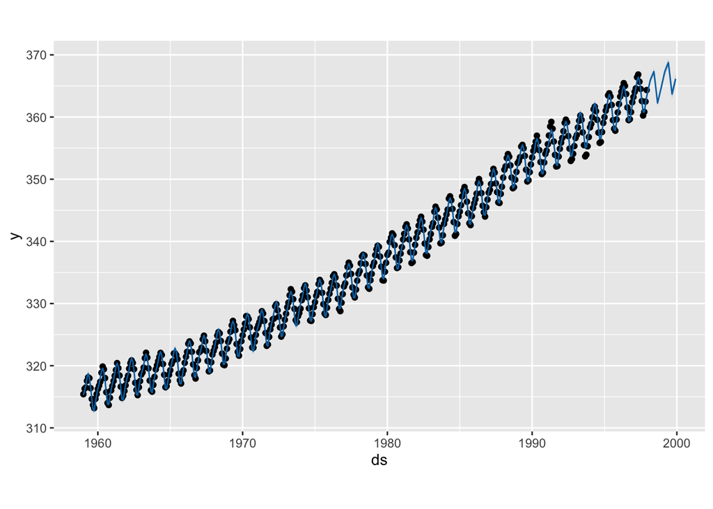

```r
# Create a quarterly forecast from the model with 8 future time intervals.
forecast = prophet::make_future_dataframe(model, periods=8, freq="quarter")

# Create a trend to predict the forecasting model.
trend = predict(model, forecast)

# Plot the model and trend along with it.
plot(model,trend)
```

As we can see, there has been a steady increase in CO2 levels every year, and it is expected to rise further in the coming years. There also seems to be some kind of seasonality with the concentration levels.

Code for a histogram depicting average CO2 levels annually is below:

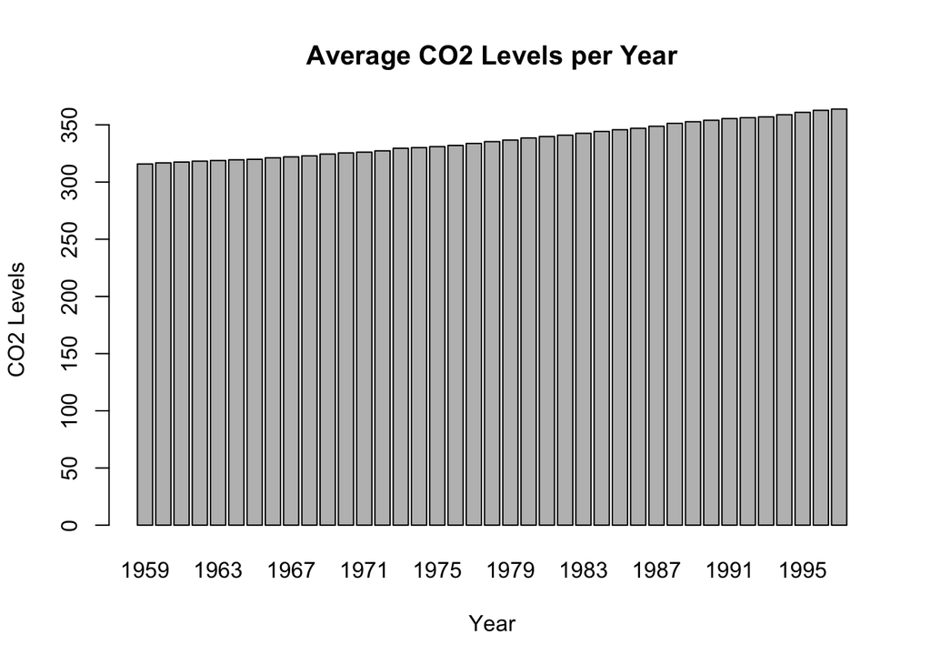

```r
co2.df = data.frame(
  ds=zoo::as.yearmon(time(co2)),
  y=co2)

# Average the co2 levels by year.
co2.df$year = as.integer(format(co2.df$ds, "%Y"))
co2_by_year = aggregate(y ~ year, data = co2.df, FUN = mean)

# Plot histogram with co2 levels on the y-axis and year on the x-axis.
barplot(co2_by_year$y,
        names.arg = co2_by_year$year,
        main = "Average CO2 Levels per Year",
        xlab = "Year",
        ylab = "CO2 Levels")
```

Evidently, there is a gradual increase in average CO2 concentration levels each year.

A linear regression of the data is seen below:

```r
lm(co2 ~ zoo::as.yearmon(time(co2)))
```

```
##
## Call:
## lm(formula = co2 ~ zoo::as.yearmon(time(co2)))
##
## Coefficients:
##                (Intercept)  zoo::as.yearmon(time(co2))
##                  -2249.774                       1.307
```

We can also zoom in and focus on a monthly forecast for a specific year, such as 1980. The code can be seen below:

```r
co2.df = data.frame(
  ds=zoo::as.yearmon(time(co2)),
  y=co2)

# Filter data for 1980.
co2.df_1980 = subset(co2.df, as.integer(format(ds, "%Y")) == 1980)

# Create a model from the data frame using historical data for 1980.
model_1980 = prophet::prophet(co2.df_1980)
```

```
## Disabling yearly seasonality. Run prophet with yearly.seasonality=TRUE to override this.
```

```
## Disabling weekly seasonality. Run prophet with weekly.seasonality=TRUE to override this.
```

```
## Disabling daily seasonality. Run prophet with daily.seasonality=TRUE to override this.
```

```
## n.changepoints greater than number of observations. Using 8
```

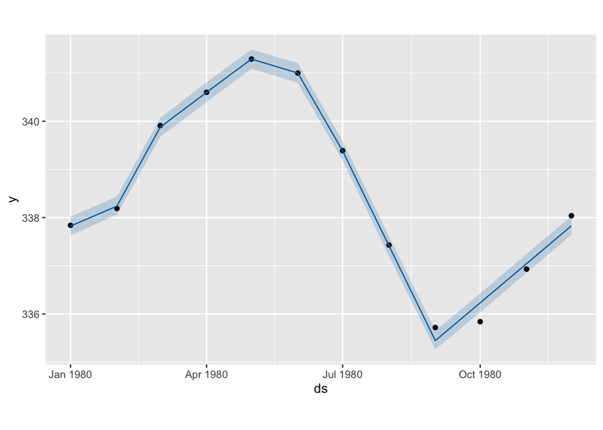

```r
# Create a monthly forecast.
future = prophet::make_future_dataframe(model_1980, periods = 12, freq = "month")
future_1980 = subset(future, as.integer(format(ds, "%Y")) == 1980)

# Create a trend to predict the forecasting model.
forecast_1980 = predict(model_1980, future_1980)

# Plot the model and trend for the specific year.
plot(model_1980, forecast_1980)
```

Evidently, in 1980 the month with the highest co2 levels was May and the lowest was September. From looking at the previous forecast spanning all years, this generally holds true for each year.

In conclusion, we succeeded in finding various seasonal and annual trends relating to the CO2 levels surrounding Mauna Loa. The overall CO2 levels have been rising year over year and are forecasted to continue doing so. Additionally, there is a seasonal trend with the CO2 levels, with concentration being the highest in the spring months and the lowest in the fall months. This data can be useful for researchers studying the volcano, as well as safety officials for monitoring the volcanic activity of the volcano and forecasting when a possible eruption could occur.